# Risk Factor Analysis

## Outcome Variable

**Outcome Variable:** pers_wast

## Predictor Variables

**Intervention Variable:** earlybf

**Adjustment Set:**

unadjusted

## Stratifying Variables

The analysis was stratified on these variable(s):

- agecat
- studyid
- country

## Data Summary

| agecat | studyid | country | earlybf | pers_wast | n_cell | n |
| --- | --- | --- | --- | --- | --- | --- |
| 0-24 months | ki0047075b-MAL-ED | BANGLADESH | 0 | 0 | 90 | 247 |
| 0-24 months | ki0047075b-MAL-ED | BANGLADESH | 0 | 1 | 5 | 247 |
| 0-24 months | ki0047075b-MAL-ED | BANGLADESH | 1 | 0 | 144 | 247 |
| 0-24 months | ki0047075b-MAL-ED | BANGLADESH | 1 | 1 | 8 | 247 |
| 0-24 months | ki0047075b-MAL-ED | BRAZIL | 0 | 0 | 117 | 217 |
| 0-24 months | ki0047075b-MAL-ED | BRAZIL | 0 | 1 | 1 | 217 |
| 0-24 months | ki0047075b-MAL-ED | BRAZIL | 1 | 0 | 98 | 217 |
| 0-24 months | ki0047075b-MAL-ED | BRAZIL | 1 | 1 | 1 | 217 |
| 0-24 months | ki0047075b-MAL-ED | INDIA | 0 | 0 | 93 | 241 |
| 0-24 months | ki0047075b-MAL-ED | INDIA | 0 | 1 | 5 | 241 |
| 0-24 months | ki0047075b-MAL-ED | INDIA | 1 | 0 | 127 | 241 |
| 0-24 months | ki0047075b-MAL-ED | INDIA | 1 | 1 | 16 | 241 |
| 0-24 months | ki0047075b-MAL-ED | NEPAL | 0 | 0 | 140 | 238 |
| 0-24 months | ki0047075b-MAL-ED | NEPAL | 0 | 1 | 1 | 238 |
| 0-24 months | ki0047075b-MAL-ED | NEPAL | 1 | 0 | 94 | 238 |
| 0-24 months | ki0047075b-MAL-ED | NEPAL | 1 | 1 | 3 | 238 |
| 0-24 months | ki0047075b-MAL-ED | PERU | 0 | 0 | 72 | 284 |
| 0-24 months | ki0047075b-MAL-ED | PERU | 0 | 1 | 0 | 284 |
| 0-24 months | ki0047075b-MAL-ED | PERU | 1 | 0 | 211 | 284 |
| 0-24 months | ki0047075b-MAL-ED | PERU | 1 | 1 | 1 | 284 |
| 0-24 months | ki0047075b-MAL-ED | SOUTH AFRICA | 0 | 0 | 100 | 268 |
| 0-24 months | ki0047075b-MAL-ED | SOUTH AFRICA | 0 | 1 | 1 | 268 |
| 0-24 months | ki0047075b-MAL-ED | SOUTH AFRICA | 1 | 0 | 166 | 268 |
| 0-24 months | ki0047075b-MAL-ED | SOUTH AFRICA | 1 | 1 | 1 | 268 |
| 0-24 months | ki0047075b-MAL-ED | TANZANIA, UNITED REPUBLIC OF | 0 | 0 | 43 | 253 |
| 0-24 months | ki0047075b-MAL-ED | TANZANIA, UNITED REPUBLIC OF | 0 | 1 | 0 | 253 |
| 0-24 months | ki0047075b-MAL-ED | TANZANIA, UNITED REPUBLIC OF | 1 | 0 | 210 | 253 |
| 0-24 months | ki0047075b-MAL-ED | TANZANIA, UNITED REPUBLIC OF | 1 | 1 | 0 | 253 |
| 0-24 months | ki1000109-EE | PAKISTAN | 0 | 0 | 285 | 377 |
| 0-24 months | ki1000109-EE | PAKISTAN | 0 | 1 | 23 | 377 |

[output cut: 114 more lines]

The following strata were considered:

- agecat: 0-24 months, studyid: ki0047075b-MAL-ED, country: BANGLADESH
- agecat: 0-24 months, studyid: ki0047075b-MAL-ED, country: BRAZIL
- agecat: 0-24 months, studyid: ki0047075b-MAL-ED, country: INDIA
- agecat: 0-24 months, studyid: ki0047075b-MAL-ED, country: NEPAL
- agecat: 0-24 months, studyid: ki0047075b-MAL-ED, country: PERU
- agecat: 0-24 months, studyid: ki0047075b-MAL-ED, country: SOUTH AFRICA
- agecat: 0-24 months, studyid: ki0047075b-MAL-ED, country: TANZANIA, UNITED REPUBLIC OF
- agecat: 0-24 months, studyid: ki1000109-EE, country: PAKISTAN
- agecat: 0-24 months, studyid: ki1000304b-SAS-CompFeed, country: INDIA
- agecat: 0-24 months, studyid: ki1017093c-NIH-Crypto, country: BANGLADESH
- agecat: 0-24 months, studyid: ki1113344-GMS-Nepal, country: NEPAL
- agecat: 0-24 months, studyid: ki1126311-ZVITAMBO, country: ZIMBABWE
- agecat: 0-24 months, studyid: kiGH5241-JiVitA-3, country: BANGLADESH
- agecat: 0-24 months, studyid: kiGH5241-JiVitA-4, country: BANGLADESH
- agecat: 0-6 months, studyid: ki0047075b-MAL-ED, country: BANGLADESH
- agecat: 0-6 months, studyid: ki0047075b-MAL-ED, country: BRAZIL
- agecat: 0-6 months, studyid: ki0047075b-MAL-ED, country: INDIA
- agecat: 0-6 months, studyid: ki0047075b-MAL-ED, country: NEPAL
- agecat: 0-6 months, studyid: ki0047075b-MAL-ED, country: PERU
- agecat: 0-6 months, studyid: ki0047075b-MAL-ED, country: SOUTH AFRICA
- agecat: 0-6 months, studyid: ki0047075b-MAL-ED, country: TANZANIA, UNITED REPUBLIC OF
- agecat: 0-6 months, studyid: ki1000109-EE, country: PAKISTAN
- agecat: 0-6 months, studyid: ki1113344-GMS-Nepal, country: NEPAL
- agecat: 6-24 months, studyid: ki0047075b-MAL-ED, country: BANGLADESH
- agecat: 6-24 months, studyid: ki0047075b-MAL-ED, country: BRAZIL
- agecat: 6-24 months, studyid: ki0047075b-MAL-ED, country: INDIA
- agecat: 6-24 months, studyid: ki0047075b-MAL-ED, country: NEPAL
- agecat: 6-24 months, studyid: ki0047075b-MAL-ED, country: PERU
- agecat: 6-24 months, studyid: ki0047075b-MAL-ED, country: SOUTH AFRICA
- agecat: 6-24 months, studyid: ki0047075b-MAL-ED, country: TANZANIA, UNITED REPUBLIC OF
- agecat: 6-24 months, studyid: ki1000109-EE, country: PAKISTAN
- agecat: 6-24 months, studyid: ki1000304b-SAS-CompFeed, country: INDIA
- agecat: 6-24 months, studyid: ki1017093c-NIH-Crypto, country: BANGLADESH
- agecat: 6-24 months, studyid: ki1113344-GMS-Nepal, country: NEPAL
- agecat: 6-24 months, studyid: ki1126311-ZVITAMBO, country: ZIMBABWE
- agecat: 6-24 months, studyid: kiGH5241-JiVitA-4, country: BANGLADESH

### Dropped Strata

Some strata were dropped due to rare outcomes:

- agecat: 0-24 months, studyid: ki0047075b-MAL-ED, country: BRAZIL
- agecat: 0-24 months, studyid: ki0047075b-MAL-ED, country: NEPAL
- agecat: 0-24 months, studyid: ki0047075b-MAL-ED, country: PERU
- agecat: 0-24 months, studyid: ki0047075b-MAL-ED, country: SOUTH AFRICA
- agecat: 0-24 months, studyid: ki0047075b-MAL-ED, country: TANZANIA, UNITED REPUBLIC OF
- agecat: 0-24 months, studyid: ki1017093c-NIH-Crypto, country: BANGLADESH
- agecat: 0-24 months, studyid: kiGH5241-JiVitA-3, country: BANGLADESH
- agecat: 0-6 months, studyid: ki0047075b-MAL-ED, country: BANGLADESH
- agecat: 0-6 months, studyid: ki0047075b-MAL-ED, country: BRAZIL
- agecat: 0-6 months, studyid: ki0047075b-MAL-ED, country: NEPAL
- agecat: 0-6 months, studyid: ki0047075b-MAL-ED, country: PERU
- agecat: 0-6 months, studyid: ki0047075b-MAL-ED, country: SOUTH AFRICA
- agecat: 0-6 months, studyid: ki0047075b-MAL-ED, country: TANZANIA, UNITED REPUBLIC OF
- agecat: 0-6 months, studyid: ki1000109-EE, country: PAKISTAN
- agecat: 6-24 months, studyid: ki0047075b-MAL-ED, country: BRAZIL
- agecat: 6-24 months, studyid: ki0047075b-MAL-ED, country: NEPAL
- agecat: 6-24 months, studyid: ki0047075b-MAL-ED, country: PERU
- agecat: 6-24 months, studyid: ki0047075b-MAL-ED, country: SOUTH AFRICA
- agecat: 6-24 months, studyid: ki0047075b-MAL-ED, country: TANZANIA, UNITED REPUBLIC OF
- agecat: 6-24 months, studyid: ki1017093c-NIH-Crypto, country: BANGLADESH

## Methods Detail

We’re interested in the causal parameters $E[Y_a]$ for all values of $a \in \mathcal{A}$. These parameters represent the mean outcome if, possibly contrary to fact, we intervened to set all units to have $A=a$. Under the randomization and positivity assumptions, these are identified by the statistical parameters $\psi_a=E_W[E_{Y|A,W}(Y|A=a,W)]$. In addition, we’re interested in the mean of $Y$, $E[Y]$ under no intervention (the observed mean). We will estimate these parameters by using SuperLearner to fit the relevant likelihood factors – $E_{Y|A,W}(Y|A=a,W)$ and $p(A=a|W)$, and then updating our likelihood fit using a joint TMLE.

For unadjusted analyses ($W=\{\}$), initial likelihoods were estimated using Lrnr_glm to estimate the simple $E(Y|A)$ and Lrnr_mean to estimate $p(A)$. For adjusted analyses, a small library containing Lrnr_glmnet, Lrnr_xgboost, and Lrnr_mean was used.

Having estimated these parameters, we will then use the delta method to estimate relative risks and attributable risks relative to a prespecified baseline level of $A$.

# Results Detail

## Results Plots

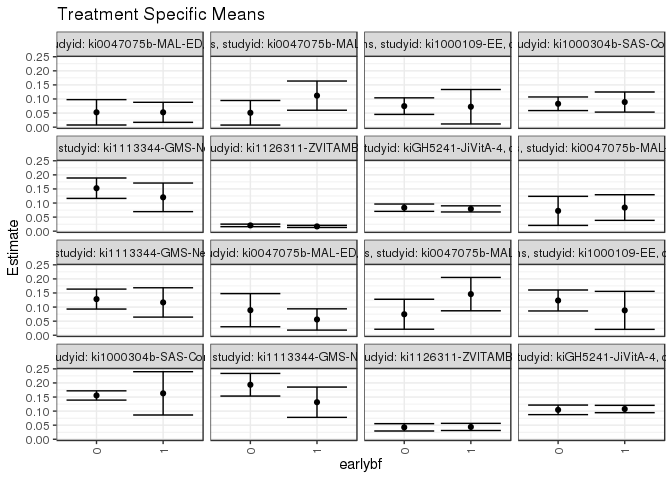

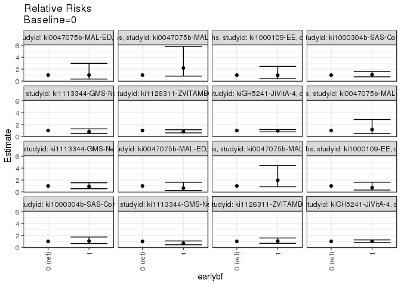

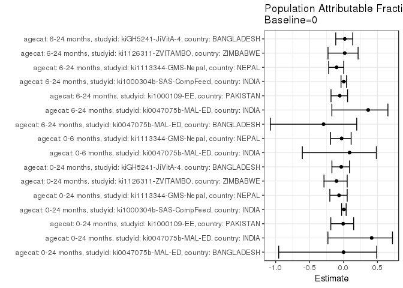

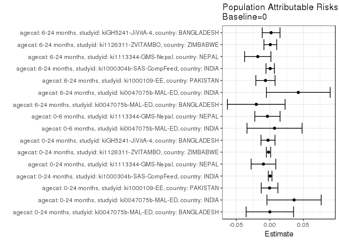

## Results Table

### Parameter: TSM

| agecat | studyid | country | intervention_level | baseline_level | estimate | ci_lower | ci_upper |
| --- | --- | --- | --- | --- | --- | --- | --- |
| 0-24 months | ki0047075b-MAL-ED | BANGLADESH | 0 | NA | 0.0526316 | 0.0076381 | 0.0976251 |
| 0-24 months | ki0047075b-MAL-ED | BANGLADESH | 1 | NA | 0.0526316 | 0.0170611 | 0.0882021 |
| 0-24 months | ki0047075b-MAL-ED | INDIA | 0 | NA | 0.0510204 | 0.0073650 | 0.0946758 |
| 0-24 months | ki0047075b-MAL-ED | INDIA | 1 | NA | 0.1118881 | 0.0601145 | 0.1636618 |
| 0-24 months | ki1000109-EE | PAKISTAN | 0 | NA | 0.0746753 | 0.0452795 | 0.1040711 |
| 0-24 months | ki1000109-EE | PAKISTAN | 1 | NA | 0.0724638 | 0.0112109 | 0.1337166 |
| 0-24 months | ki1000304b-SAS-CompFeed | INDIA | 0 | NA | 0.0830040 | 0.0588611 | 0.1071469 |
| 0-24 months | ki1000304b-SAS-CompFeed | INDIA | 1 | NA | 0.0891089 | 0.0534033 | 0.1248146 |
| 0-24 months | ki1113344-GMS-Nepal | NEPAL | 0 | NA | 0.1526316 | 0.1164391 | 0.1888241 |
| 0-24 months | ki1113344-GMS-Nepal | NEPAL | 1 | NA | 0.1202532 | 0.0694898 | 0.1710166 |
| 0-24 months | ki1126311-ZVITAMBO | ZIMBABWE | 0 | NA | 0.0205425 | 0.0160305 | 0.0250546 |
| 0-24 months | ki1126311-ZVITAMBO | ZIMBABWE | 1 | NA | 0.0169681 | 0.0131855 | 0.0207506 |
| 0-24 months | kiGH5241-JiVitA-4 | BANGLADESH | 0 | NA | 0.0833768 | 0.0703893 | 0.0963642 |
| 0-24 months | kiGH5241-JiVitA-4 | BANGLADESH | 1 | NA | 0.0791196 | 0.0682796 | 0.0899596 |
| 0-6 months | ki0047075b-MAL-ED | INDIA | 0 | NA | 0.0721649 | 0.0205628 | 0.1237671 |
| 0-6 months | ki0047075b-MAL-ED | INDIA | 1 | NA | 0.0839161 | 0.0383778 | 0.1294544 |
| 0-6 months | ki1113344-GMS-Nepal | NEPAL | 0 | NA | 0.1282799 | 0.0928546 | 0.1637052 |
| 0-6 months | ki1113344-GMS-Nepal | NEPAL | 1 | NA | 0.1164384 | 0.0643570 | 0.1685198 |
| 6-24 months | ki0047075b-MAL-ED | BANGLADESH | 0 | NA | 0.0888889 | 0.0299679 | 0.1478099 |
| 6-24 months | ki0047075b-MAL-ED | BANGLADESH | 1 | NA | 0.0559441 | 0.0181964 | 0.0936917 |
| 6-24 months | ki0047075b-MAL-ED | INDIA | 0 | NA | 0.0744681 | 0.0212809 | 0.1276553 |
| 6-24 months | ki0047075b-MAL-ED | INDIA | 1 | NA | 0.1459854 | 0.0867315 | 0.2052393 |
| 6-24 months | ki1000109-EE | PAKISTAN | 0 | NA | 0.1233333 | 0.0860739 | 0.1605927 |
| 6-24 months | ki1000109-EE | PAKISTAN | 1 | NA | 0.0882353 | 0.0207286 | 0.1557420 |
| 6-24 months | ki1000304b-SAS-CompFeed | INDIA | 0 | NA | 0.1555755 | 0.1391015 | 0.1720496 |
| 6-24 months | ki1000304b-SAS-CompFeed | INDIA | 1 | NA | 0.1630435 | 0.0861546 | 0.2399324 |
| 6-24 months | ki1113344-GMS-Nepal | NEPAL | 0 | NA | 0.1935484 | 0.1533623 | 0.2337344 |
| 6-24 months | ki1113344-GMS-Nepal | NEPAL | 1 | NA | 0.1315789 | 0.0777892 | 0.1853687 |
| 6-24 months | ki1126311-ZVITAMBO | ZIMBABWE | 0 | NA | 0.0423913 | 0.0293687 | 0.0554140 |
| 6-24 months | ki1126311-ZVITAMBO | ZIMBABWE | 1 | NA | 0.0438247 | 0.0311592 | 0.0564902 |
| 6-24 months | kiGH5241-JiVitA-4 | BANGLADESH | 0 | NA | 0.1044614 | 0.0874923 | 0.1214305 |
| 6-24 months | kiGH5241-JiVitA-4 | BANGLADESH | 1 | NA | 0.1074868 | 0.0944457 | 0.1205279 |

### Parameter: E(Y)

| agecat | studyid | country | intervention_level | baseline_level | estimate | ci_lower | ci_upper |
| --- | --- | --- | --- | --- | --- | --- | --- |
| 0-24 months | ki0047075b-MAL-ED | BANGLADESH | NA | NA | 0.0526316 | 0.0247278 | 0.0805354 |
| 0-24 months | ki0047075b-MAL-ED | INDIA | NA | NA | 0.0871369 | 0.0514552 | 0.1228187 |
| 0-24 months | ki1000109-EE | PAKISTAN | NA | NA | 0.0742706 | 0.0477670 | 0.1007741 |
| 0-24 months | ki1000304b-SAS-CompFeed | INDIA | NA | NA | 0.0834553 | 0.0601989 | 0.1067118 |
| 0-24 months | ki1113344-GMS-Nepal | NEPAL | NA | NA | 0.1431227 | 0.1135034 | 0.1727420 |
| 0-24 months | ki1126311-ZVITAMBO | ZIMBABWE | NA | NA | 0.0186080 | 0.0156964 | 0.0215196 |
| 0-24 months | kiGH5241-JiVitA-4 | BANGLADESH | NA | NA | 0.0806665 | 0.0720540 | 0.0892791 |
| 0-6 months | ki0047075b-MAL-ED | INDIA | NA | NA | 0.0791667 | 0.0449364 | 0.1133970 |
| 0-6 months | ki1113344-GMS-Nepal | NEPAL | NA | NA | 0.1247444 | 0.0954276 | 0.1540611 |
| 6-24 months | ki0047075b-MAL-ED | BANGLADESH | NA | NA | 0.0686695 | 0.0361280 | 0.1012111 |
| 6-24 months | ki0047075b-MAL-ED | INDIA | NA | NA | 0.1168831 | 0.0753620 | 0.1584042 |
| 6-24 months | ki1000109-EE | PAKISTAN | NA | NA | 0.1168478 | 0.0839821 | 0.1497135 |
| 6-24 months | ki1000304b-SAS-CompFeed | INDIA | NA | NA | 0.1561462 | 0.1410608 | 0.1712315 |
| 6-24 months | ki1113344-GMS-Nepal | NEPAL | NA | NA | 0.1755725 | 0.1429662 | 0.2081788 |
| 6-24 months | ki1126311-ZVITAMBO | ZIMBABWE | NA | NA | 0.0431393 | 0.0340586 | 0.0522200 |
| 6-24 months | kiGH5241-JiVitA-4 | BANGLADESH | NA | NA | 0.1063872 | 0.0957820 | 0.1169924 |

### Parameter: RR

| agecat | studyid | country | intervention_level | baseline_level | estimate | ci_lower | ci_upper |
| --- | --- | --- | --- | --- | --- | --- | --- |
| 0-24 months | ki0047075b-MAL-ED | BANGLADESH | 0 | 0 | 1.0000000 | 1.0000000 | 1.000000 |
| 0-24 months | ki0047075b-MAL-ED | BANGLADESH | 1 | 0 | 1.0000000 | 0.3362978 | 2.973555 |
| 0-24 months | ki0047075b-MAL-ED | INDIA | 0 | 0 | 1.0000000 | 1.0000000 | 1.000000 |
| 0-24 months | ki0047075b-MAL-ED | INDIA | 1 | 0 | 2.1930070 | 0.8290467 | 5.800976 |
| 0-24 months | ki1000109-EE | PAKISTAN | 0 | 0 | 1.0000000 | 1.0000000 | 1.000000 |
| 0-24 months | ki1000109-EE | PAKISTAN | 1 | 0 | 0.9703844 | 0.3819299 | 2.465494 |
| 0-24 months | ki1000304b-SAS-CompFeed | INDIA | 0 | 0 | 1.0000000 | 1.0000000 | 1.000000 |
| 0-24 months | ki1000304b-SAS-CompFeed | INDIA | 1 | 0 | 1.0735502 | 0.7076965 | 1.628537 |
| 0-24 months | ki1113344-GMS-Nepal | NEPAL | 0 | 0 | 1.0000000 | 1.0000000 | 1.000000 |
| 0-24 months | ki1113344-GMS-Nepal | NEPAL | 1 | 0 | 0.7878656 | 0.4854858 | 1.278579 |
| 0-24 months | ki1126311-ZVITAMBO | ZIMBABWE | 0 | 0 | 1.0000000 | 1.0000000 | 1.000000 |
| 0-24 months | ki1126311-ZVITAMBO | ZIMBABWE | 1 | 0 | 0.8259972 | 0.6040408 | 1.129512 |
| 0-24 months | kiGH5241-JiVitA-4 | BANGLADESH | 0 | 0 | 1.0000000 | 1.0000000 | 1.000000 |
| 0-24 months | kiGH5241-JiVitA-4 | BANGLADESH | 1 | 0 | 0.9489404 | 0.7766449 | 1.159459 |
| 0-6 months | ki0047075b-MAL-ED | INDIA | 0 | 0 | 1.0000000 | 1.0000000 | 1.000000 |
| 0-6 months | ki0047075b-MAL-ED | INDIA | 1 | 0 | 1.1628372 | 0.4738821 | 2.853432 |
| 0-6 months | ki1113344-GMS-Nepal | NEPAL | 0 | 0 | 1.0000000 | 1.0000000 | 1.000000 |
| 0-6 months | ki1113344-GMS-Nepal | NEPAL | 1 | 0 | 0.9076899 | 0.5365896 | 1.535440 |
| 6-24 months | ki0047075b-MAL-ED | BANGLADESH | 0 | 0 | 1.0000000 | 1.0000000 | 1.000000 |
| 6-24 months | ki0047075b-MAL-ED | BANGLADESH | 1 | 0 | 0.6293706 | 0.2444123 | 1.620652 |
| 6-24 months | ki0047075b-MAL-ED | INDIA | 0 | 0 | 1.0000000 | 1.0000000 | 1.000000 |
| 6-24 months | ki0047075b-MAL-ED | INDIA | 1 | 0 | 1.9603754 | 0.8621143 | 4.457729 |
| 6-24 months | ki1000109-EE | PAKISTAN | 0 | 0 | 1.0000000 | 1.0000000 | 1.000000 |
| 6-24 months | ki1000109-EE | PAKISTAN | 1 | 0 | 0.7154214 | 0.3142881 | 1.628531 |
| 6-24 months | ki1000304b-SAS-CompFeed | INDIA | 0 | 0 | 1.0000000 | 1.0000000 | 1.000000 |
| 6-24 months | ki1000304b-SAS-CompFeed | INDIA | 1 | 0 | 1.0480020 | 0.6339000 | 1.732620 |
| 6-24 months | ki1113344-GMS-Nepal | NEPAL | 0 | 0 | 1.0000000 | 1.0000000 | 1.000000 |
| 6-24 months | ki1113344-GMS-Nepal | NEPAL | 1 | 0 | 0.6798246 | 0.4298034 | 1.075286 |
| 6-24 months | ki1126311-ZVITAMBO | ZIMBABWE | 0 | 0 | 1.0000000 | 1.0000000 | 1.000000 |
| 6-24 months | ki1126311-ZVITAMBO | ZIMBABWE | 1 | 0 | 1.0338135 | 0.6780580 | 1.576222 |
| 6-24 months | kiGH5241-JiVitA-4 | BANGLADESH | 0 | 0 | 1.0000000 | 1.0000000 | 1.000000 |
| 6-24 months | kiGH5241-JiVitA-4 | BANGLADESH | 1 | 0 | 1.0289621 | 0.8445668 | 1.253617 |

### Parameter: PAR

| agecat | studyid | country | intervention_level | baseline_level | estimate | ci_lower | ci_upper |
| --- | --- | --- | --- | --- | --- | --- | --- |
| 0-24 months | ki0047075b-MAL-ED | BANGLADESH | 0 | NA | 0.0000000 | -0.0352958 | 0.0352958 |
| 0-24 months | ki0047075b-MAL-ED | INDIA | 0 | NA | 0.0361165 | -0.0042449 | 0.0764779 |
| 0-24 months | ki1000109-EE | PAKISTAN | 0 | NA | -0.0004048 | -0.0128400 | 0.0120304 |
| 0-24 months | ki1000304b-SAS-CompFeed | INDIA | 0 | NA | 0.0004514 | -0.0023056 | 0.0032084 |
| 0-24 months | ki1113344-GMS-Nepal | NEPAL | 0 | NA | -0.0095089 | -0.0278606 | 0.0088428 |
| 0-24 months | ki1126311-ZVITAMBO | ZIMBABWE | 0 | NA | -0.0019345 | -0.0051212 | 0.0012522 |
| 0-24 months | kiGH5241-JiVitA-4 | BANGLADESH | 0 | NA | -0.0027102 | -0.0131183 | 0.0076979 |
| 0-6 months | ki0047075b-MAL-ED | INDIA | 0 | NA | 0.0070017 | -0.0340114 | 0.0480149 |
| 0-6 months | ki1113344-GMS-Nepal | NEPAL | 0 | NA | -0.0035355 | -0.0223477 | 0.0152767 |
| 6-24 months | ki0047075b-MAL-ED | BANGLADESH | 0 | NA | -0.0202194 | -0.0632153 | 0.0227765 |
| 6-24 months | ki0047075b-MAL-ED | INDIA | 0 | NA | 0.0424150 | -0.0050254 | 0.0898554 |
| 6-24 months | ki1000109-EE | PAKISTAN | 0 | NA | -0.0064855 | -0.0208015 | 0.0078304 |
| 6-24 months | ki1000304b-SAS-CompFeed | INDIA | 0 | NA | 0.0005706 | -0.0056784 | 0.0068197 |
| 6-24 months | ki1113344-GMS-Nepal | NEPAL | 0 | NA | -0.0179759 | -0.0376012 | 0.0016494 |
| 6-24 months | ki1126311-ZVITAMBO | ZIMBABWE | 0 | NA | 0.0007480 | -0.0087316 | 0.0102276 |
| 6-24 months | kiGH5241-JiVitA-4 | BANGLADESH | 0 | NA | 0.0019258 | -0.0113423 | 0.0151939 |

### Parameter: PAF

| agecat | studyid | country | intervention_level | baseline_level | estimate | ci_lower | ci_upper |
| --- | --- | --- | --- | --- | --- | --- | --- |
| 0-24 months | ki0047075b-MAL-ED | BANGLADESH | 0 | NA | 0.0000000 | -0.9554502 | 0.4886088 |
| 0-24 months | ki0047075b-MAL-ED | INDIA | 0 | NA | 0.4144801 | -0.2301792 | 0.7213141 |
| 0-24 months | ki1000109-EE | PAKISTAN | 0 | NA | -0.0054499 | -0.1876173 | 0.1487750 |
| 0-24 months | ki1000304b-SAS-CompFeed | INDIA | 0 | NA | 0.0054088 | -0.0286322 | 0.0383232 |
| 0-24 months | ki1113344-GMS-Nepal | NEPAL | 0 | NA | -0.0664388 | -0.2021536 | 0.0539547 |
| 0-24 months | ki1126311-ZVITAMBO | ZIMBABWE | 0 | NA | -0.1039611 | -0.2883484 | 0.0540369 |
| 0-24 months | kiGH5241-JiVitA-4 | BANGLADESH | 0 | NA | -0.0335978 | -0.1713928 | 0.0879879 |
| 0-6 months | ki0047075b-MAL-ED | INDIA | 0 | NA | 0.0884428 | -0.6070774 | 0.4829517 |
| 0-6 months | ki1113344-GMS-Nepal | NEPAL | 0 | NA | -0.0283420 | -0.1906466 | 0.1118378 |
| 6-24 months | ki0047075b-MAL-ED | BANGLADESH | 0 | NA | -0.2944444 | -1.0791678 | 0.1941072 |
| 6-24 months | ki0047075b-MAL-ED | INDIA | 0 | NA | 0.3628842 | -0.1722863 | 0.6537394 |
| 6-24 months | ki1000109-EE | PAKISTAN | 0 | NA | -0.0555039 | -0.1846086 | 0.0595304 |
| 6-24 months | ki1000304b-SAS-CompFeed | INDIA | 0 | NA | 0.0036545 | -0.0371916 | 0.0428920 |
| 6-24 months | ki1113344-GMS-Nepal | NEPAL | 0 | NA | -0.1023843 | -0.2190740 | 0.0031359 |
| 6-24 months | ki1126311-ZVITAMBO | ZIMBABWE | 0 | NA | 0.0173389 | -0.2288794 | 0.2142250 |
| 6-24 months | kiGH5241-JiVitA-4 | BANGLADESH | 0 | NA | 0.0181019 | -0.1148905 | 0.1352300 |